# Simple Linear Regression: Assumptions

2025

## Assumptions of simple linear regression

- The relationship between \(X\) and \(Y\) is **linear**.
- The residuals are **independent**.
- The residuals are **normally distributed**.
- The residuals have **constant variance** (homoscedasticity).

## Assumption: Linearity

- The expected value of \(Y\) given \(X\) is a linear function:

  \[ \mathbb{E}[Y \mid X] = \beta_0 + \beta_1 X \]
- If this assumption is violated, the model is **misspecified** and predictions or hypothesis tests may be misleading.

## Non-linearity example

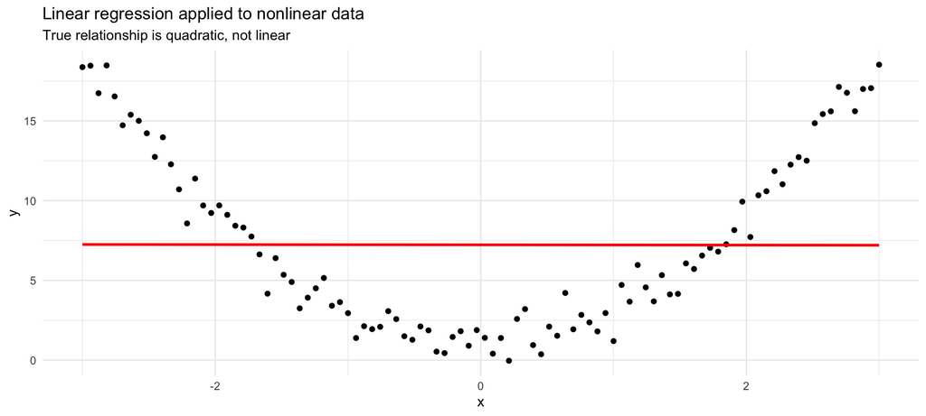

## Non-linearity example

```
##
## Call:
## lm(formula = y ~ x, data = d)
##
## Residuals:
##    Min     1Q Median     3Q    Max
## -7.268 -4.920 -1.695  4.262 11.319
##
## Coefficients:
##              Estimate Std. Error t value Pr(>|t|)
## (Intercept)  7.230099   0.557821  12.961   <2e-16 ***
## x           -0.007442   0.318853  -0.023    0.981
## ---
## Signif. codes:  0 '***' 0.001 '**' 0.01 '*' 0.05 '.' 0.1 ' ' 1
##
## Residual standard error: 5.578 on 98 degrees of freedom
## Multiple R-squared:  5.559e-06,  Adjusted R-squared:  -0.0102
## F-statistic: 0.0005448 on 1 and 98 DF,  p-value: 0.9814
```

## Non-linearity example

- The true relationship between \(x\) and \(y\) is clearly non-linear.
- The slope for \(x\) is **not significantly different from zero**.
- This might lead you to falsely conclude that there is no relationship between \(x\) and \(y\).
- But we know the true relationship is quadratic and applying a linear model is an instance of model misspecification.

## Diagnosing linearity

- Plot **residuals vs fitted values**.
- If the relationship is linear, the residuals should hover randomly around zero.
- Curvature or systematic patterns suggest model misspecification.

## Diagnosing linearity

```r
# plot residuals vs fitted values
d[, fitted := predict(lm(y ~ x, data=d))]
d[, residual := resid(lm(y ~ x, data=d))]

ggplot(d, aes(x=fitted, y=residual)) +
  geom_point() +
  geom_hline(yintercept=0, linetype="dashed", color="red") +
  theme_minimal() +
  labs(title="Residuals vs Fitted Values")
```

## Diagnosing linearity

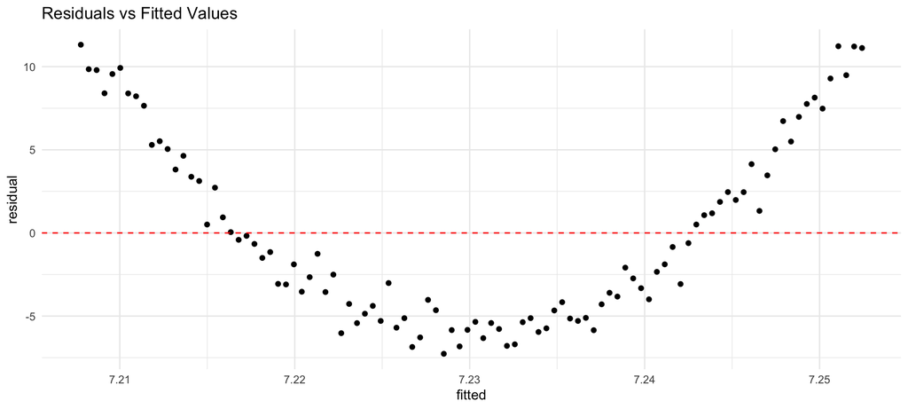

## Assumption: Independence of residuals

- Each residual should be independent of the others.
- Violations often lead to underestimated standard errors and consequently inflated type I error rates.
- This assumption is almost always violated in time series or clustered data (e.g., cognitive science experiments that measure learning across time).

## Diagnosing independence

- Look for patterns in residuals plotted against observation order.

## Diagnosing independence

```r
# plots residuals against observation order
d[, order := 1:.N]
d[, residual := resid(lm(y ~ x, data=d))]
ggplot(d, aes(x=order, y=residual)) +
  geom_point() +
  geom_hline(yintercept=0, linetype="dashed", color="red") +
  theme_minimal() +
  labs(title="Residuals vs Observation Order")
```

## Diagnosing independence

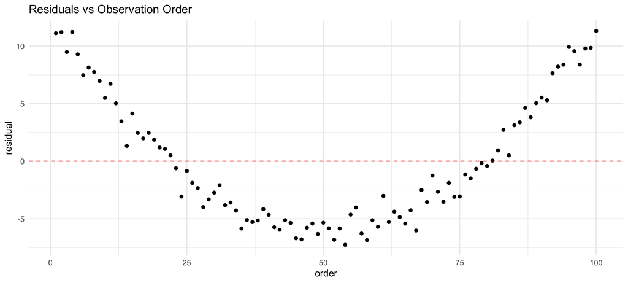

## Assumption: Normality of residuals

- Residuals should be normally distributed.

## Diagnosing normality

- Use a histogram or density plot of residuals.
- A Q-Q plot is more sensitive to deviations from normality. **I haven’t shown you these**
- Small deviations are okay if \(n\) is large because of the Central Limit Theorem.

## Diagnosing normality

```r
# plot histogram of residuals
d[, residual := resid(lm(y ~ x, data=d))]
ggplot(d, aes(x=residual)) +
  geom_histogram(bins=15, color="white", fill="steelblue") +
  theme_minimal() +
  labs(title="Histogram of Residuals")
```

## Diagnosing normality

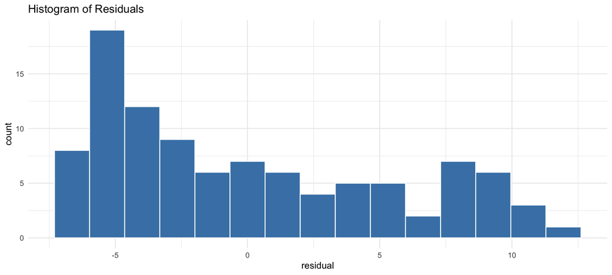

## Consequences of non-normality

- We use a \(t\)-test to ask whether a regression coefficient (e.g., \(\beta_1\)) is significantly different from zero:

\[ t = \frac{\widehat{\beta}_1 - 0}{\widehat{\sigma}_{\widehat{\beta}_1}} \]

- This test assumes that the sampling distribution of \(\widehat{\beta}_1\) is approximately normal under the null hypothesis.
- If the residuals are normally distributed, then \(\widehat{\beta}_1\) is normally distributed too.
- If the residuals are not normal, the \(t\)-test may give misleading \(p\)-values and confidence intervals—especially in small samples.

## Non-normal residuals can inflate false positives

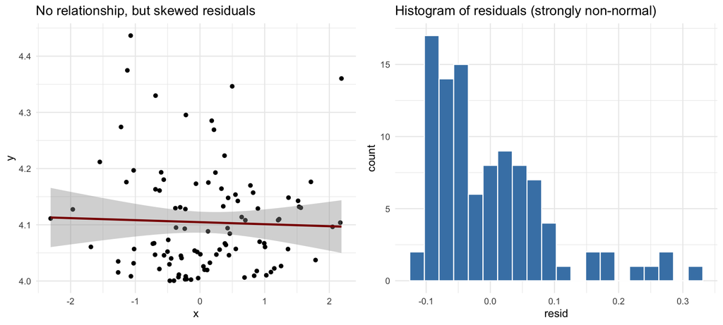

## Non-normal residuals can inflate false positives

- Type I error rate is can be higher than 5%.

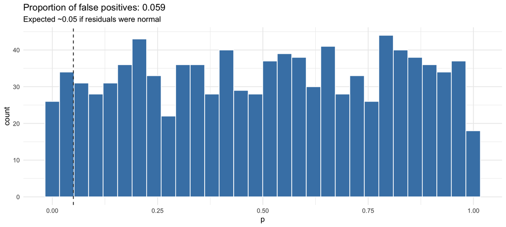

## Regression is robust to non-normality

- Regression is robust to non-normality if your sample size is large and residuals are not wildly skewed or heavy-tailed.

## Assumption: Homoscedasticity

- Residuals should have constant variance across all values of \(X\).
- If not, standard errors may be biased, leading to invalid inference.

## Diagnosing homoscedasticity

- Again, use the **residuals vs fitted values** plot.
- Look for a **funnel shape** — increasing or decreasing spread suggests heteroscedasticity.

## Diagnosing homoscedasticity

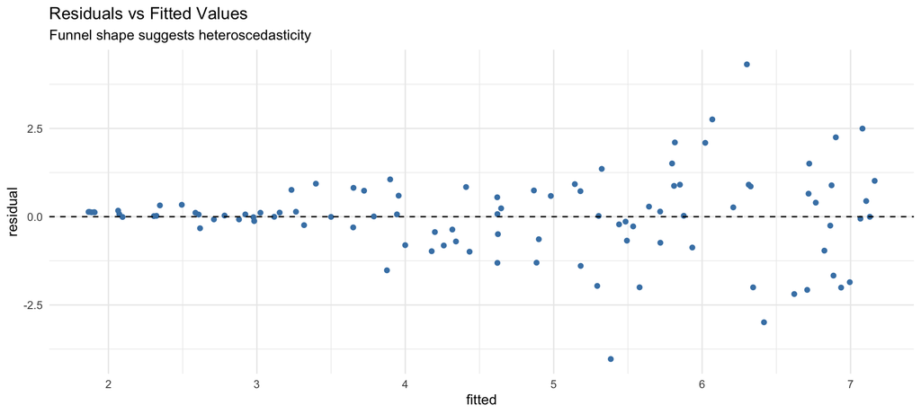

## Consequences of heteroscedasticity

- Let’s simulate data with predictor \(x\) is unrelated to \(y\) but with residuals with variance that increases with \(x\). This creates **heteroscedasticity**.

[figure not shown]

## Simulation: Heteroscedasticity and false positives

- Even though \(x\) has no effect, the heteroscedasticity can lead to inflated type I error rates.

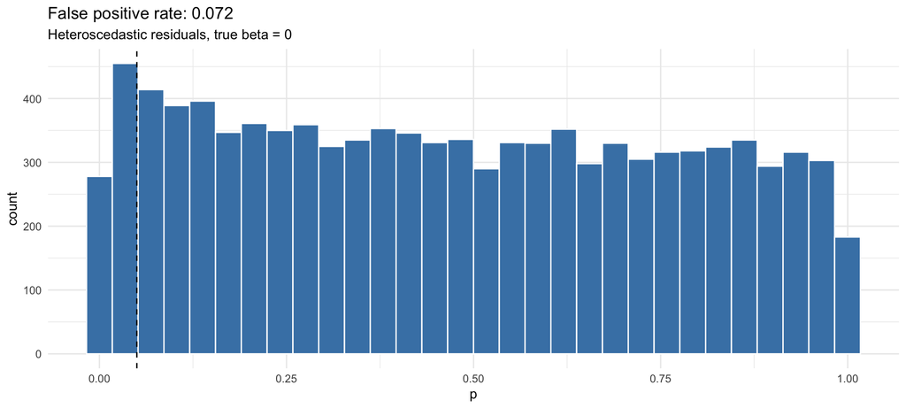

## Summary: Assumptions of Linear Regression

| Assumption | Consequence of Violation | Robust? | Solution Exists? |
| --- | --- | --- | --- |
| Linearity | Model is misspecified; predictions and inference may be misleading | No | Yes |
| Independence | Inflated type I error rate | No | Yes |
| Homoscedasticity | Inflated type I error rate | Somewhat | Yes |
| Normality of residuals | Inflated type I error rate | Yes if \(n\) is large | Yes |